# S1.1 — extract_regions(): dalla mappa dei cluster alle regioni connesse

geo_spatialtrans · binario S · sessione S1.1 (2026-10-07)

Author

Claude (esecuzione), Luca Vedovelli (approvazioni)

Published

October 7, 2026

**Note**

**Verdetto in una riga.** `extract_regions()` è corretta sul pannello di 57 input, comprese 5 sezioni Visium HD reali e 30 ROI A1–A6: area esatta, poligoni validi, componenti identiche a due implementazioni indipendenti (`imager` nel test, `scipy` nel ricalcolo del revisore); C11 in budget. La controprova CP-1 ha **smentito la mia previsione**: il poligono di Moore sui centri sbaglia solo dello 0.7–1.4 % sui sintetici, quindi la tolleranza del 2 % non ha potere su regioni grandi (il check esatto sì). Il revisore ha trovato **due bug** (stride stimato su input sparsi, etichette fuse), ora corretti o segnalati con regressioni; i numeri del pannello non cambiano. Rilievo principale per il design: sulle mappe reali il filtro a 100 µm² tratterebbe come extracellulare dal 2.7 al 27 % del tessuto (A6 cuore ~22 %). Stato: **chiusa con riserve**.

# 1. Pre-registrazione

Testo integrale in `results/S1.1/S1.1_preregistration.md`, committato (`28a1eec`) **prima** di qualsiasi codice. Approvazione di Luca: «procedi» (2026-10-07).

**Obiettivo unico.** `extract_regions(clust, pixel_size_um, min_region_area_um2)` in `R/04b1_extract_regions.R`: mappa di cluster in pixel → regioni connesse (4-vicinato) come `sfc_POLYGON` in µm + `region_df` (+ `excluded_df`). Niente centroidi, Voronoi o preset.

**Deviazioni dal design v1.1 §5.1, approvate prima del codice.**

1. Contorno sui **lati** dei pixel, non tracciamento di Moore sui centri: il contorno sui centri perde mezzo pixel lungo tutto il perimetro e ignora i buchi. Il Moore letterale è la controprova CP-1.
2. Semplificazione `st_simplify(dTolerance = 0.5 µm, preserveTopology = TRUE)` come da design, con costo misurato; `simplify_tol_um = 0` = solo vertici collineari.
3. Rilevamento dello **stride** (`generate_synthetic_tissue()` campiona 1 pixel ogni *s* sopra 1 Mpx).
4. `min_region_area_um2 = 100` resta il default (senza fonte); se ne misura il costo.

**Chiarimenti di implementazione dichiarati prima di eseguire**: union-find vettorizzato sulle run di riga invece di una BFS per pixel (stessa motivazione del design: nessuna dipendenza nuova; equivalenza verificata da C4 contro `imager::label`); poligono = unione GEOS dei rettangoli delle run; filtro sull’area esatta in pixel; C11 valutato su due griglie 4000×4000.

**Aggiunte dopo i risultati (dichiarate, non pre-registrate).** (a) Analisi **esplorativa** di CP-1 sui ROI reali a 8 µm e sulle sole regioni ≥ 100 µm² (`tools/S1.1_cp1_posthoc.R`), aggiunta dopo il FAIL di CP-1; (b) correzione di un difetto di prestazioni scoperto da C11 (sez. 2.4) e nuova misura; entrambe le misure sono riportate; (c) dopo la revisione avversariale: correzione di due bug (RA-17 stride, RA-18 etichette), tre protezioni (warning su stride stimato e su tolleranza > mezzo pixel, `n_holes` = NA per non-POLYGON), 6 asserzioni nuove (5 regressioni `REG-*` costruite sui casi del revisore + CP-4b). Tutti i numeri di questo report vengono dal codice corretto; sui 57 input del pannello nessun valore è cambiato (verificato colonna per colonna e, indipendentemente, dal revisore in 114/114 esecuzioni, FX-23/24).

| id | Attesa | Soglia |
| --- | --- | --- |
| C1 | Σ area (esatta) = n_px·(s·px)² | errore relativo < 1e-9 |
| C1s | idem, semplificata | ≤ 2 % globale; 95° pct per regione ≤ 2 % (WARN) |
| C2 | poligoni validi, non vuoti, solo POLYGON | 100 % |
| C3 | n_regioni ≥ k | sì |
| C4 | componenti = `imager::label` (4-vicinato) | multinsieme (cluster, n_px) identico |
| C5 | ritorno al raster | 100 % esatta; ≥ 98 % semplificata |
| C6 | sovrapposizioni + scoperto | 0 esatta; ≤ 1 % semplificata (WARN) |
| C7 | filtro esatto; px = 2 → aree ×4, perimetri ×2 | esatto |
| C8 | ripetizione e righe permutate | identico |
| C9 | orientamento (pixel (3,5); forma a L) | esatto |
| C10 | errori espliciti | 4/4 |
| C11 | 4000×4000 | ≤ 2 min, ≤ 3.2 GB (WARN) |
| CP-1 | Moore sui centri **fallisce** C1 | 10×10 → 81; \|errore\| > 2 % su I1–I4 |
| CP-2 | cluster unico; regione sotto soglia | 1 regione; esclusa e in `excluded_df` |
| CP-3 | nullo spaziale (etichette permutate) sulle 5 mappe reali | n_regioni reale ≪ nullo **e** frazione esclusa reale < nullo, 5/5 |
| CP-4 | verità nota (I5) | aree delle 30 patch esatte |

**Input (57 + 2 di prestazioni).** 11 avversari; I1–I4 sintetici 600×600 (complessità 1–4, `cluster_image` k = 4); I5 = `label_matrix` (verità nota); I6 6800×6500 (stride 6); 5 mappe graphclust 8 µm intere (A1, A2/A3, A4, A5, A6) + 30 ROI di R2 (5 per archetipo, A3 = ROI stromali del CRC) + 5 nulli; P1/P2 4000×4000. md5 delle sorgenti reali in `S1.1_real_sources_md5.csv`, md5 degli input in `S1.1_inputs.csv`.

# 2. Check C — correttezza software

Asserzioni di `R/testing/test_S1.1.R`: 711 PASS · 1 WARN · 4 FAIL su 716 (C11 in sez. 2.4).

| check | PASS | WARN | FAIL |
| --- | --- | --- | --- |
| ADV | 8 | 0 | 0 |
| ADV/CP-2 | 2 | 0 | 0 |
| C1 | 57 | 0 | 0 |
| C10 | 1 | 0 | 0 |
| C1s | 114 | 0 | 0 |
| C2 | 57 | 0 | 0 |
| C3 | 57 | 0 | 0 |
| C4 | 52 | 0 | 0 |
| C4b | 58 | 0 | 0 |
| C5 | 104 | 0 | 0 |
| C6 | 103 | 1 | 0 |
| C7 | 69 | 0 | 0 |
| C8 | 18 | 0 | 0 |
| C9 | 2 | 0 | 0 |
| CP-1 | 1 | 0 | 4 |
| CP-3 | 1 | 0 | 0 |
| CP-4 | 1 | 0 | 0 |
| CP-4b | 1 | 0 | 0 |
| REG-RA17 | 3 | 0 | 0 |
| REG-RA18 | 1 | 0 | 0 |
| REG-RA20 | 1 | 0 | 0 |

## 2.1 Area, validità, componenti (C1–C5, C7, C8)

Su **tutti** i 57 input: area esatta conservata (errore 0, ≤ 1e-9), poligoni validi e solo `POLYGON`, componenti identiche a `imager::label` (52/52 input confrontati; i 5 nulli esclusi per costo, coperti da C1), ritorno al raster pixel-identico (esatto) e ≥ 98 % (semplificato: in realtà 100 % ovunque), filtro esatto, scala esatta, riproducibilità e invarianza all’ordine delle righe (18/18).

Per input (i 30 ROI sono riassunti nella sez. 3). C6 sempl. = (sovrapposizione + scoperto)/area tessuto.

[output not shown]

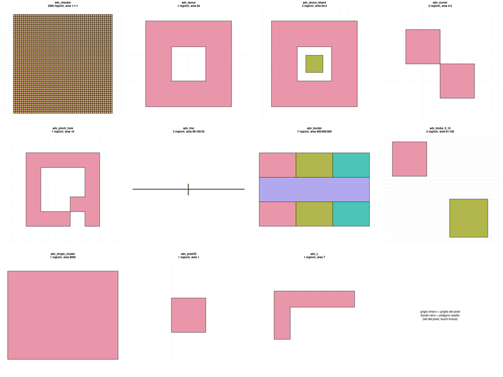

Fig. 1 — Avversari: poligoni esatti (bordo nero) sopra la griglia dei pixel. Ciambella 84 = 100 − 16 con 1 buco; ciambella con isola: 2 regioni; contatto d’angolo: 2 componenti; buco che tocca il guscio in un vertice: POLYGON valido; scacchiera: 2 500 componenti; 9×9 = 81 µm² escluso a 100 µm², 10×10 tenuto.

Attese pre-registrate sugli avversari, orientamento (C9) ed errori (C10).

| check | input | metrica | valore | soglia | esito |
| --- | --- | --- | --- | --- | --- |
| C4b | I6_syn6800x6500_c2 | stride rilevato = stride ricostruito nel test | 6 6 | uguali | PASS |
| ADV | adv_checker | n componenti | 2500 | 2500 | PASS |
| ADV | adv_corner | n componenti | 2 | 2 | PASS |
| ADV | adv_pinch_hole | n componenti | 1 | 1 | PASS |
| ADV | adv_line | n componenti | 3 | 3 | PASS |
| ADV | adv_border | n componenti | 7 | 7 | PASS |
| ADV | adv_donut | area / buchi | 84 1 | 84 / 1 | PASS |
| ADV | adv_donut_island | regioni (ciambella + isola) | 2 | 2 (3 con il buco come fondo) | PASS |
| ADV | adv_pinch_hole | area, buco che tocca il guscio in un vertice | 16 | 16, valido | PASS |
| ADV/CP-2 | adv_single_cluster | regioni / area | 1 8000 | 1 / 8000 | PASS |
| ADV/CP-2 | adv_blobs_9_10 | 9x9 escluso (81) in excluded_df, 10x10 tenuto (100) | 81 100 | 81 escluso / 100 tenuto | PASS |
| C9 | adv_pixel35 | bbox px=1 / px=2 | 2,4,3,5 / 4,8,6,10 | 2,4,3,5 / 4,8,6,10 | PASS |
| C9 | adv_L | bbox; (4.5,0.5) e (0.5,2.5) dentro, (0.5,4.5) fuori | 0,0,5,3 110 | 0,0,5,3; 110 | PASS |
| C10 | adv_corner | errori espliciti (px mancante, px<=0, colonna mancante, coord. non intere) | missing_px,px_le0,no_col,non_int | 4/4 | PASS |
| C4b | I6_syn6800x6500_c2 | stride atteso 6 | 6 | 6 | PASS |

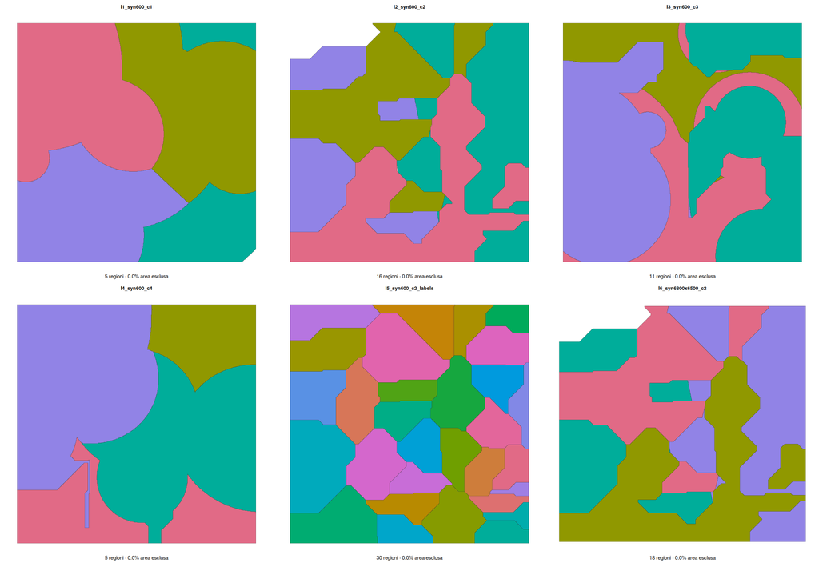

Fig. 2 — Sintetici I1–I6: regioni colorate per cluster (grigio = componenti escluse dal filtro; qui quasi assenti).

## 2.2 Costo della semplificazione (C1s, C5, C6)

Con `dTolerance = 0.5 µm` e `preserveTopology = TRUE` l’area totale non cambia in nessun input (C1s = 0): sulle scale di 1 µm/px i vertici a gradino sono quasi tutti conservati e a 8 µm/px la tolleranza è un sedicesimo di pixel. La semplificazione però **sposta** area: nei sintetici sovrapposizione e scoperto valgono ~1e-4 dell’area di tessuto, e nell’avversario `adv_pinch_hole` (buco che tocca il guscio in un vertice) 1.56 % → **WARN C6** (soglia 1 %). È un costo reale e localizzato nelle tacche larghe un pixel; non tocca le mappe a 8 µm. Il revisore aggiunge tre precisazioni: (RA-21) C1s = 0 non significa geometria intatta: in I2 l’area è invariata ma la differenza simmetrica è 62.5 µm², cioè area spostata per compensazione; (RA-23) la definizione di «scoperto» non conta l’area che la semplificazione aggiunge fuori dal tessuto (sarebbe più corretto usare la differenza simmetrica); (RA-20) con pixel più piccoli della tolleranza la semplificazione distrugge forme sottili (linea 800×1 px a 0.25 µm/px: −50 %). Ora un warning segnala tolleranze maggiori di mezzo pixel effettivo; la scelta di esprimere la tolleranza in pixel è in BL-046.

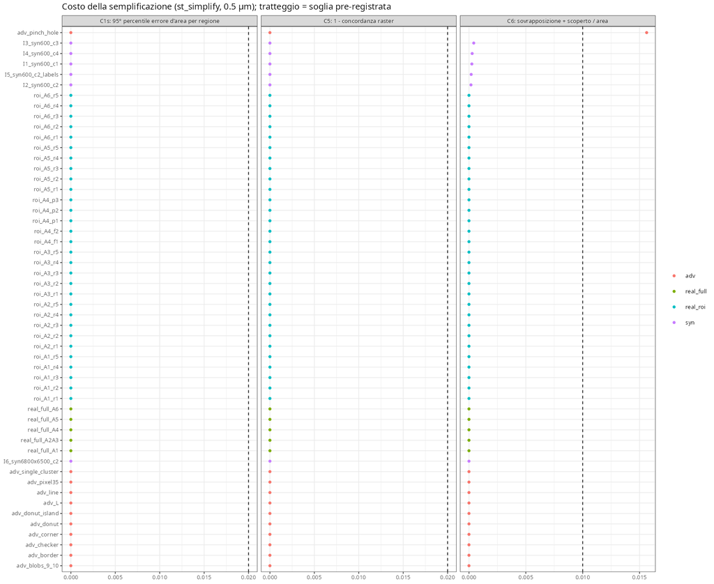

Fig. 8 — Costo della semplificazione per input; tratteggio = soglia pre-registrata.

## 2.3 Difetti trovati durante lo sviluppo (prima dei numeri di questo report)

1. **Unione «coverage» di GEOS** (`st_union(is_coverage = TRUE)`): sullo smoke test la ciambella risultava con l’area giusta ma **non valida** (3 buchi) e una forma a U diventava `MULTIPOLYGON`. Causa: i rettangoli delle run condividono lati con giunzioni a T, che CoverageUnion non gestisce. Corretto con l’unione normale; C2 e la Fig. 1 ne sono il controllo.
2. **Criterio di arresto di Jacob** nella variante di Moore (solo controprova): non termina sulle linee larghe 1 px; sostituito con «stessa prima mossa dal pixel di partenza».
3. **`imager::as.cimg` rifiuta le matrici 1×1** (il banco di prova falliva su `adv_pixel35`): bordo di fondo aggiunto alla griglia nel test; non tocca la funzione.
4. **Revisione avversariale — stride stimato su input sparsi (RA-17).** Input validi a stride 1 ma sparsi venivano letti come campionati: (1,1),(4,1) a 8 µm → stride 3, una regione da 1 152 µm² invece di due bin da 64 µm² esclusi; (1,1),(5001,5001) → 3.2·10⁹ µm². Errore silenzioso, invisibile a C4b (che stima lo stride dagli stessi dati: tautologico). Correzione adottata: **warning** esplicito quando lo stride stimato è > 1 senza essere dichiarato e `info$stride_source`; con `stride = 1` il risultato è corretto. Senza stride dichiarato il risultato su input sparsi resta sbagliato (FX-01/02): rendere lo stride obbligatorio è una decisione di design aperta (BL-042). Nessun falso positivo su 563 sottoinsiemi reali per cluster (FX-27).
5. **Revisione avversariale — etichette fuse (RA-18).** `as.numeric()` fondeva etichette distinte con lo stesso valore («1»/«01», fattore «1»/«1.0»). Ora gli id numerici si usano solo se la conversione è iniettiva. Effetto collaterale (FX-26): `cluster_id` è intero (non più double) per colonne intere: valori identici, checksum degli RDS di `e7f2562` diversi.

**Potere del test (RA-22).** Il revisore stima che circa 128 delle 710 asserzioni originali non possano fallire per un errore plausibile della funzione o ne condividano il punto cieco: C3 (discende da C7), C4b (due stime dello stride dagli stessi dati), C7 scala (garantita da `polys * px`), CP-4. Le asserzioni con potere reale sono C1, C2, C4 (contro `imager`), C5, C6, C8, C9, C10 e gli avversari. Il conteggio totale va letto con questa riserva.

## 2.4 Prestazioni (C11)

C11 su griglie piene 4000×4000 (16 M pixel); budget 2 min / 3.2 GB.

| giro | input | componenti | regioni | tempo (s) | RSS dopo il caricamento (MB) | RSS massimo processo (MB) | esito |
| --- | --- | --- | --- | --- | --- | --- | --- |
| 1 (prima della correzione) | P1_4000_c2_labels | 30 | 30 | 30.63 | 308 | 5210 | WARN |
| 1 (prima della correzione) | P2_4000_c4_quant4 | 54 | 47 | 27.66 | 308 | 5208 | WARN |
| 2 (codice finale) | P1_4000_c2_labels | 30 | 30 | 8.25 | 308 | 1295 | PASS |
| 2 (codice finale) | P2_4000_c4_quant4 | 54 | 47 | 8.35 | 308 | 1296 | PASS |

Il primo giro ha dato **WARN** (5.2 GB, 30 s) e ha rivelato un difetto: il controllo dei duplicati `anyDuplicated()` su un `data.frame` di 16 M righe costruisce 16 M stringhe (≈ 24 s e la maggior parte della memoria) ed era fuori dal cronometro interno (che riportava 6 s). Corretto con una chiave numerica e cronometro dall’ingresso; il secondo giro (codice finale) è **PASS**: 8.3 s e 1 296 MB. Nota: P2 (complessità 4 quantizzata) ha solo 54 componenti: il caso «frammentato» pre-registrato non è risultato frammentato. **Caso peggiore misurato dal revisore (RA-16):** una mappa 4000² con 4 etichette casuali a 8 µm/px (3.19 M regioni) richiede 863 s e 9.5 GB, cioè ~7× il budget in tempo e ~3× in memoria. Il costo cresce con il numero di poligoni costruiti (~3 700 regioni/s). Sulle sezioni reali a 8 µm (≤ 0.7 M bin) l’output d’uso costa 25 s / 0.43 GB (A6); a 2 µm (~16× i bin) il problema diventerebbe reale (BL-045). Anche la memoria cresce con il riquadro che contiene i pixel, non con il loro numero (RA-24).

# 3. Check B — descrittivo (A1–A6), senza PASS/FAIL

La ROADMAP non prevede check B per S1.1 (macro-regioni, non biologia) e non esistono riferimenti con fonte: la sezione è **descrittiva**, come pre-registrato.

ROI reali (graphclust 8 µm) per archetipo, 5 ROI × 1 mm².

| A | ROI | regioni ≥100 (med.) | mediana pesata area (µm²) | area esclusa med. [min–max] | componenti di 1 bin (med.) | cluster |
| --- | --- | --- | --- | --- | --- | --- |
| A1 | 5 | 786 | 2 816 | 4.2 % [4.1 %–5.2 %] | 43 % | 23 |
| A2 | 5 | 863 | 5 248 | 6.6 % [5.5 %–8.2 %] | 52 % | 12 |
| A3 | 5 | 576 | 546 688 | 5.0 % [3.9 %–5.4 %] | 58 % | 12 |
| A4 | 5 | 317 | 647 168 | 4.0 % [2.7 %–5.9 %] | 64 % | 11 |
| A5 | 5 | 581 | 22 848 | 3.9 % [3.2 %–6.4 %] | 49 % | 20 |
| A6 | 5 | 1926 | 704 | 22.7 % [20.2 %–27.4 %] | 66 % | 13 |

Sintetici (k-means su intensità, 1 µm/px) e sezioni reali intere.

| input | regioni | mediana pesata area (µm²) | area esclusa | componenti di 1 px/bin | cluster |
| --- | --- | --- | --- | --- | --- |
| I1_syn600_c1 | 5 | 108 553 | 0.00 % | 0 % | 4 |
| I2_syn600_c2 | 16 | 58 138 | 0.01 % | 5 % | 4 |
| I3_syn600_c3 | 11 | 82 188 | 0.00 % | 14 % | 4 |
| I4_syn600_c4 | 5 | 118 082 | 0.00 % | 0 % | 4 |
| I5_syn600_c2_labels | 30 | 14 491 | 0.00 % | 0 % | 30 |
| I6_syn6800x6500_c2 | 18 | 7 097 328 | 0.00 % | 0 % | 4 |
| real_full_A1 | 21 659 | 2 752 | 5.48 % | 47 % | 26 |
| real_full_A2A3 | 24 983 | 20 032 | 6.08 % | 56 % | 17 |
| real_full_A4 | 14 511 | 60 224 | 15.35 % | 75 % | 29 |
| real_full_A5 | 21 556 | 34 496 | 5.65 % | 51 % | 27 |
| real_full_A6 | 72 296 | 1 088 | 20.65 % | 66 % | 13 |

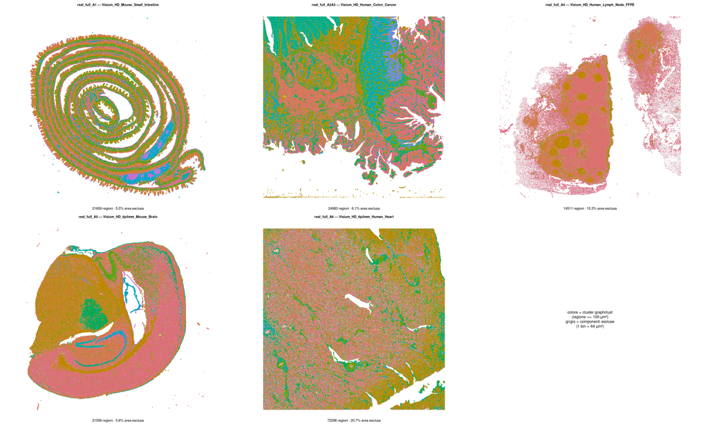

Fig. 3 — Mappe graphclust 8 µm intere: regioni ≥ 100 µm² colorate per cluster.

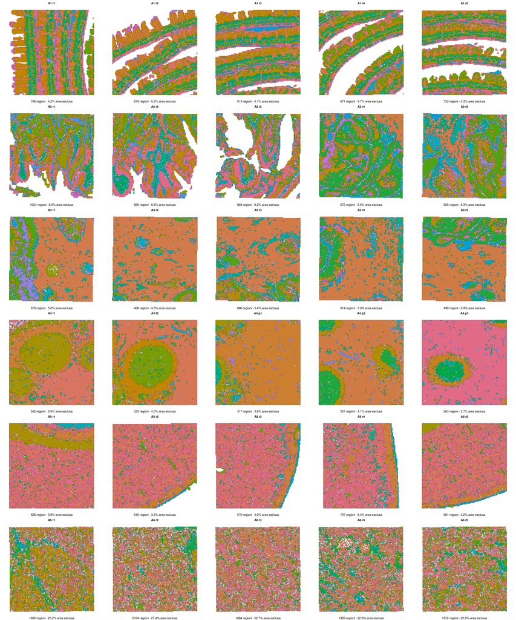

Fig. 4 — ROI per archetipo (righe A1–A6, 5 ROI ciascuno). Grigio = componenti escluse dal filtro a 100 µm² (bin isolati): evidenti in A6 (cuore).

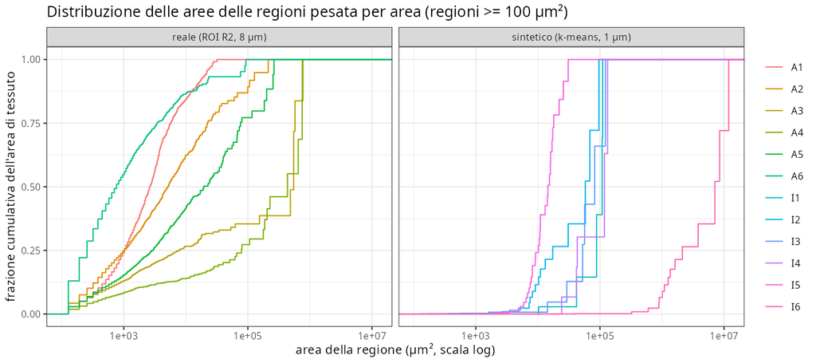

Fig. 5 — (a) Distribuzione delle aree delle regioni pesata per area; (b) frammentazione per archetipo e per sintetico.

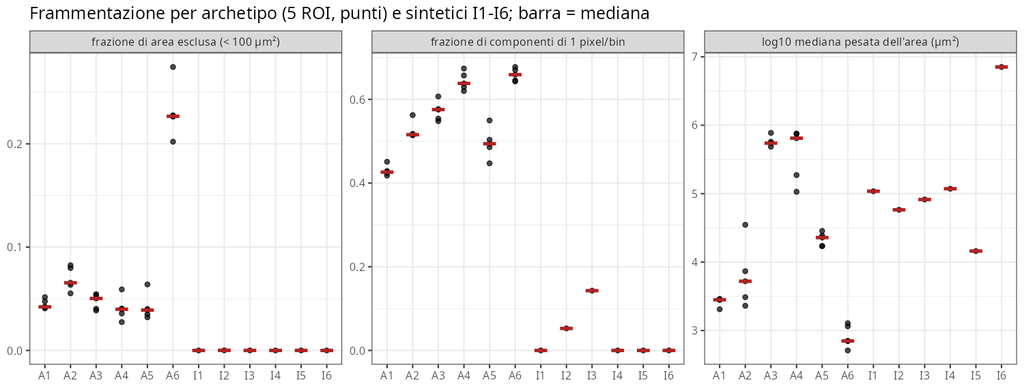

Fig. 5 — (a) Distribuzione delle aree delle regioni pesata per area; (b) frammentazione per archetipo e per sintetico.

**Osservazioni.**

1. **Le mappe sintetiche sono lisce, quelle reali frammentate.** I1–I6 producono 5–30 regioni con ~0 % di area esclusa; i ROI reali 263–2 104 regioni per ROI di 1 mm², con mediane per archetipo del 43–66 % di componenti di un solo bin e il 2.7–27 % di area sotto i 100 µm². Il simulatore, nella sua forma attuale (`cluster_image` con peso spaziale 0.6), non genera la micro-struttura delle mappe di cluster reali.
2. **A6 (cuore) è l’archetipo più frammentato** (area esclusa mediana 22.7 %, mediana pesata dell’area ~700 µm²): coerente con l’aspettativa che una mappa isotropa e grossolana descriva male un tessuto anisotropo, ma qui la frammentazione viene dai cluster trascrizionali, non dalla geometria cellulare.
3. **Il default `min_region_area_um2 = 100` scarta tessuto.** Il design (§5.1, passo 4) tratta le componenti escluse come «spazio extracellulare macro». Sulle mappe reali sono **tessuto** (bin `in_tissue` con un cluster assegnato): con il default, Step 2 tratterebbe come extracellulare il 3–27 % del tessuto. Sui sintetici il problema non si vede perché la frammentazione è quasi nulla.
4. **Cautela.** Graphclust a 8 µm riflette anche il rumore di campionamento dei bin (poche UMI per bin), non solo regioni istologiche: la frammentazione reale non è una «verità» da imitare. È però l’input che un utente fornirebbe se usasse mappe reali.
5. **Fondo artificiale in A4 (RA-07).** Le mappe contengono solo i bin con etichetta graphclust. I bin `in_tissue` senza etichetta diventano fondo: 31 (A1), 517 (A2/A3), **62 933 in A4 (17.9 % del tessuto)**, 32 (A5), 1 110 (A6). In A4 questo crea buchi e frammentazione artificiali: la frazione esclusa della sezione intera A4 (15.3 %) e il CP-3 di A4 ne risentono (BL-049).

# 4. Controprove

## CP-1 — Moore sui centri: previsione smentita

CP-1 (pre-registrata): la variante doveva fallire C1 (|errore| > 2 %).

| input | metrica | valore | soglia | esito |
| --- | --- | --- | --- | --- |
| adv_blobs_9_10 | Moore sui centri: area del 10x10 | 81 | 81 (fallisce C1) | PASS |
| I1_syn600_c1 | Moore sui centri: errore relativo area globale | -0.00744334 | \|err\| > 0.02 (fallisce C1) | FAIL |
| I2_syn600_c2 | Moore sui centri: errore relativo area globale | -0.01414 | \|err\| > 0.02 (fallisce C1) | FAIL |
| I3_syn600_c3 | Moore sui centri: errore relativo area globale | -0.0124597 | \|err\| > 0.02 (fallisce C1) | FAIL |
| I4_syn600_c4 | Moore sui centri: errore relativo area globale | -0.00895139 | \|err\| > 0.02 (fallisce C1) | FAIL |

La previsione era che il contorno sui centri sbagliasse l’area di più del 2 % su I1–I4. **Non è così**: −0.7, −1.4, −1.2, −0.9 %. Sul blob 10×10 l’area è 81 come previsto. L’errore relativo di un contorno sui centri scala come perimetro/area (Fig. 6: i punti seguono la curva del quadrato); I1–I4 hanno 5–19 componenti di decine di migliaia di pixel, per cui l’errore è sotto il 2 %. Conseguenze:

- la tolleranza del 2 % della ROADMAP **non ha potere** contro un errore sistematico di mezzo pixel quando le regioni sono grandi; il criterio che distingue i due metodi è C1 esatto (1e-9), che la variante supera di circa 7 ordini di grandezza (confermato dal revisore, RA-14);
- **esplorativo, non pre-registrato**: sui ROI reali a 8 µm (regioni piccole) la stessa variante sbaglia da -74 % a 18 % (positivo in A4: i buchi ignorati vengono contati come area). Lì il 2 % la intercetterebbe subito.

La scelta del contorno sui lati resta giustificata (errore 0 in ogni condizione), ma il motivo «il 2 % basta a scartare Moore» era sbagliato. Per S1.3–S1.4 (territori cellulari di 50–300 µm² a 1 µm/px, regime della Fig. 6 sotto 10³ pixel) il poligono di Moore sbaglierebbe del 10–26 % (curva del quadrato a 50–300 pixel). Precisazione del revisore (RA-14): il difetto è del **poligono di Moore**, non di qualunque contorno «sui centri»: un contorno a marching squares (livello 0.5, buchi sottratti) sbaglia solo dello 0.0007–0.003 % su I1–I4 e dell’1–20 % sui ROI. Resta approssimato, mentre il contorno sui lati dei pixel è esatto per costruzione.

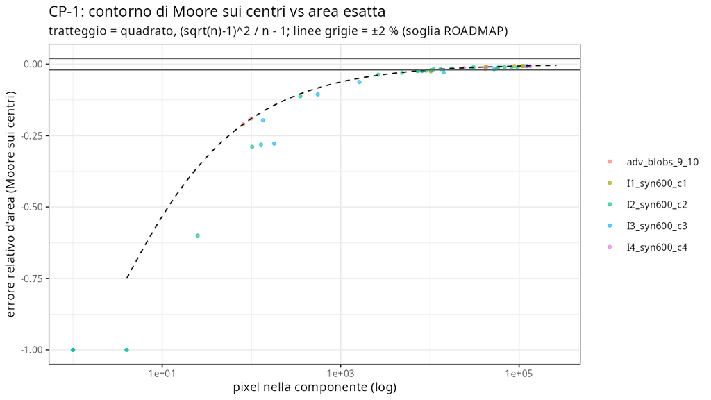

Fig. 6 — Errore d’area della variante di Moore per componente (I1–I4 e blob); tratteggio = quadrato.

## CP-2 — Cluster unico e regione sotto soglia

`adv_single_cluster`: 1 regione di 8 000 µm² (PASS). `adv_blobs_9_10`: il 9×9 (81 µm²) è in `excluded_df`, il 10×10 (100 µm²) è una regione (PASS; il confronto è `≥`).

## CP-3 — Nullo spaziale

Mappe reali vs etichette permutate fra i bin (stessa composizione, seed 20261007).

| dataset | regioni reale | regioni nullo | rapporto | esclusa reale | esclusa nullo | componenti reale | componenti nullo |
| --- | --- | --- | --- | --- | --- | --- | --- |
| A1 | 21 659 | 38 206 | 1.76 | 5.5 % | 75.0 % | 40 940 | 302 131 |
| A2A3 | 24 983 | 67 409 | 2.70 | 6.1 % | 67.7 % | 56 376 | 416 959 |
| A4 | 14 511 | 42 981 | 2.96 | 15.3 % | 53.5 % | 58 727 | 197 223 |
| A5 | 21 556 | 57 328 | 2.66 | 5.6 % | 62.4 % | 44 122 | 306 764 |
| A6 | 72 296 | 113 936 | 1.58 | 20.7 % | 51.4 % | 209 607 | 455 554 |

**PASS** secondo il criterio scritto (reale < nullo per entrambe le metriche, 5/5), ricalcolato identico dal revisore (RA-03/05). Precisazione: la pre-registrazione diceva «≪» per il numero di regioni senza quantificarlo; il rapporto osservato è solo 1.6–3.0, perché nel nullo molte coppie di bin adiacenti hanno lo stesso cluster per caso e superano i 100 µm². Le metriche che separano nettamente reale e nullo sono la frazione esclusa (5–21 % vs 51–75 %) e il numero di componenti (×2–7).

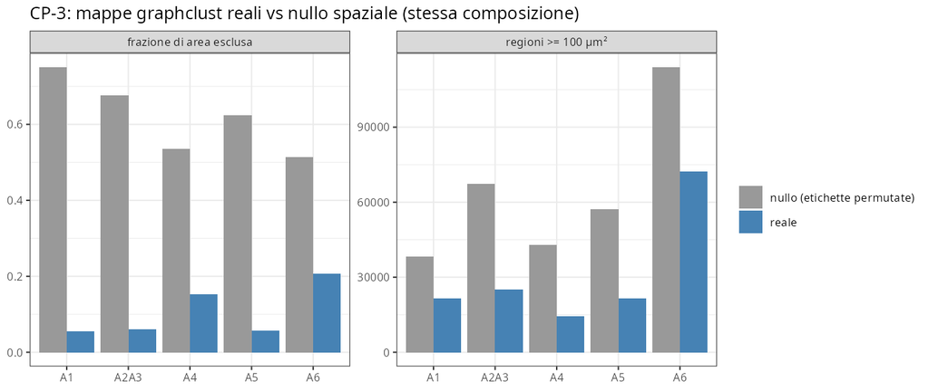

Fig. 7 — CP-3: confronto reale/nullo; mappa A1 reale e permutata.

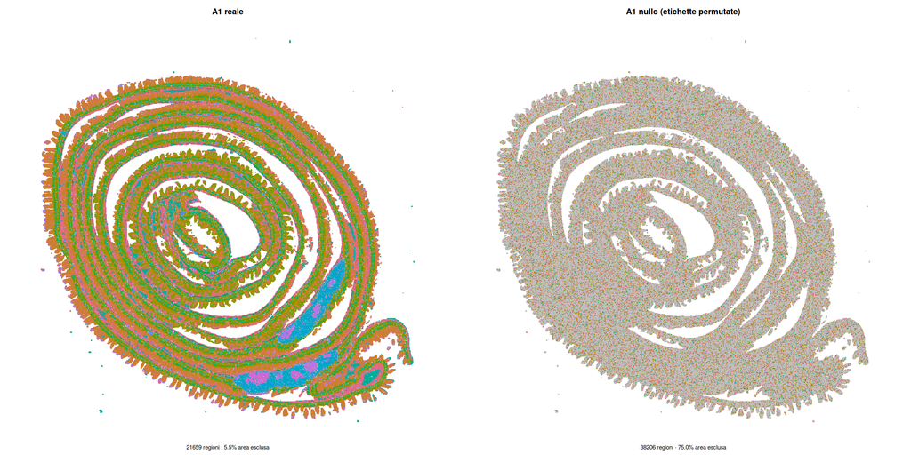

Fig. 7 — CP-3: confronto reale/nullo; mappa A1 reale e permutata.

## CP-4 — Verità nota (I5)

Le 30 patch di Voronoi (Manhattan) di I5 sono recuperate con area esatta (30/30; da 1 933 a 30 802 pixel), ciascuna come una sola componente. **Rilievo del revisore (RA-09):** l’asserzione CP-4 come scritta è tautologica (la somma dei pixel per cluster è la stessa per qualunque partizione in componenti). L’informazione non banale, cioè una sola componente per patch, è ora valutata da **CP-4b** (aggiunta dopo la revisione): 30/30 PASS.

# Verdetto

- **Stato: chiusa con riserve.**
- **Check C**: 711 PASS, 1 WARN (C6 su `adv_pinch_hole`), 4 FAIL (tutti CP-1) su 716 asserzioni, con la riserva sul potere di ~128 di esse (RA-22); C11 PASS al giro finale (WARN di memoria al primo giro, difetto corretto).
- **Check B**: descrittivo, come pre-registrato; nessun PASS/FAIL.
- **Controprove**: CP-1 FAIL (previsione di grandezza sbagliata, non un difetto della funzione); CP-2, CP-3, CP-4, CP-4b PASS (CP-3 regge sulla frazione esclusa più che sul numero di regioni).

**Riserve (→ `docs/BACKLOG.md`).**

1. **BL-042** — Stride: senza dichiarazione, su input sparsi il risultato resta sbagliato (con warning). Decidere fra stride obbligatorio, stride trasmesso dai metadati di `generate_synthetic_tissue()`, o warning. *Decisione di Luca.*
2. **BL-043** — Semantica di `min_region_area_um2` (design §5.1, passo 4): sulle mappe reali le componenti escluse sono tessuto (2.7–27 %), non spazio extracellulare. Opzioni: assegnarle alla regione circostante (filtro di maggioranza), o tenerle come regioni. Revisione del design prima di S1.2.
3. **BL-044** — Le mappe sintetiche (`cluster_image`, k = 4, peso spaziale 0.6) sono lisce (5–30 regioni) rispetto alle mappe di cluster reali (10⁴–10⁵ regioni per sezione). Valutare se il simulatore debba generare micro-struttura, o se la frammentazione reale sia rumore da non imitare.
4. **BL-045** — Prestazioni con milioni di regioni (RA-16: 863 s, 9.5 GB) e memoria proporzionale al riquadro (RA-24): rilevante per mappe a 2 µm.
5. **BL-046** — Tolleranza di semplificazione espressa in µm assoluti: a 1 µm/px sposta geometria (C6 WARN, RA-21), sotto il mezzo pixel distrugge forme sottili (RA-20). Esprimerla in pixel o rendere 0 il default; C6 con differenza simmetrica (RA-23).
6. **BL-047** — CP-1: una tolleranza relativa di area (2 % qui, 1 % per C2 in S1.3) non ha potere contro errori sistematici di bordo su regioni grandi; per S1.3 servono anche check esatti o su regioni piccole.
7. **BL-048** — Pratica di pre-registrazione: niente «≪» senza numero (RA-05); asserzioni che possano fallire (RA-09, RA-22).
8. **BL-049** — In A4 il 17.9 % dei bin di tessuto non ha etichetta graphclust (RA-07): fondo artificiale nelle mappe reali.

# Revisione avversariale

Sotto-agente indipendente (2026-10-07), con accesso al server, ai dati sorgente e al codice al commit `e7f2562`, senza usare né `R/04b1_extract_regions.R` né il test per i ricalcoli (Python + `scipy.ndimage.label` a 4-vicinato, Moore e marching squares propri). Esito: **26 rilievi: 13 confermati, 2 discrepanze, 11 rilievi di metodo**. Tutti i numeri riportati sono stati riprodotti, fra cui le componenti di 9 input (9/9, nullo compreso), aree e regioni delle 10 mappe intere, le 5 mappe reali ricostruite dalle sorgenti (md5 10/10), area e validità di tutte le 209 607 componenti di A6, CP-1, CP-4, C11 (3 ripetizioni) e il conteggio delle asserzioni.

- **Discrepanze**: RA-17 (stride stimato su input sparsi) e RA-18 (etichette fuse): accolte, corrette o segnalate (sez. 2.3), con regressioni nel test.
- **Rilievi accolti nel testo**: RA-05 (CP-3 «≪»), RA-07 (A4), RA-09 (CP-4 tautologico → CP-4b), RA-14 (Moore ≠ qualunque contorno sui centri), RA-16 e RA-24 (prestazioni), RA-20, RA-21 e RA-23 (semplificazione), RA-22 (potere del test), RA-25 (`n_holes`), RA-02 (convenzione d’angolo: l’ultimo blocco campionato può superare il bordo dell’immagine di ≤ s−1 pixel).
- **Deviazioni dichiarate dal revisore**: il multinsieme completo delle dimensioni è stato confrontato su 1 nullo su 5 (gli altri 4 solo con i conteggi); il primo giro di C11 non è riverificabile perché il codice che lo ha prodotto precede `e7f2562`.
- **Verifica delle correzioni** (stesso revisore, seconda ripresa): 22 casi avversari e regressione su 57 input × 2 configurazioni, valori identici in 114/114 esecuzioni, warning dove atteso e nessun falso positivo su 563 sottoinsiemi reali. Il ramo RA-25 non è esercitabile con input reali. Dopo il suo rilievo FX-24 (con `>=` il warning sulla tolleranza scattava su ogni chiamata d’uso a 1 µm/px) la soglia è diventata `>`. `results/S1.1/S1.1_adversarial_fixcheck.csv`.

Tabelle complete: `results/S1.1/S1.1_adversarial_review.csv`, `S1.1_adversarial_fixcheck.csv`; script in `results/S1.1/review/`.

Revisione avversariale: 26 rilievi (valori riportati e ricalcolati nel CSV).

| id | compito | affermazione | esito | nota |
| --- | --- | --- | --- | --- |
| RA-01 | 1 | n_components (4-vicinato, per cluster) e multinsieme (cluster, n_px) per 9 input | confermato | null_full_A2A3 non aveva C4 nel test (NA): questo ricalcolo copre la lacuna per quel nullo. Dimensione massima: A1 2508 px, A6 8974 px, nullo A2A3 16 px; bin singoli: A1 19281, A6 137311, nullo A2A3 3… |
| RA-02 | 1 | I6 campionato con stride 6 | confermato | Convenzione d’angolo: il bin x copre [(x-1), (x-1+6)] µm, quindi l’ultimo bin arriva a 6804 > 6800 µm (sovrastima ai bordi <= 0.1 %) e i blocchi sono spostati di 3 µm rispetto a una convenzione centra… |
| RA-03 | 2 | n regioni >= 100 µm², n escluse e frazione di area esclusa per 5 real_full e 5 null_full | confermato | A 8 µm la soglia 100 µm² esclude esattamente le componenti di 1 bin: n_excluded = n componenti di 1 px in 10/10 |
| RA-04 | 2 | La permutazione del nullo conserva la composizione | confermato | Una sola realizzazione per dataset; con 0.3-0.7 M bin la variabilità fra permutazioni è trascurabile per questi conteggi (non verificato con altre permutazioni) |
| RA-05 | 2 | CP-3: n regioni reale ≪ nullo (pre-registrazione) valutato con ‘<’ | rilievo | La pre-registrazione dice ‘≪’ senza soglia numerica; il test usa ‘<’. Per A6 un rapporto di 1.6 difficilmente è ‘≪’. La parte sulla frazione esclusa è invece nettamente separata (5-21 % contro 51-75 %… |
| RA-06 | 3 | real_full_A1 corrisponde alle sorgenti (clusters.csv + tissue_positions.parquet, x = array_col+1, y = array_row+1) | confermato | Script 03_sources.py; nessun bin clusterizzato fuori dal tessuto, nessun barcode di clusters.csv assente dal parquet |
| RA-07 | 3 | Il fondo delle mappe reali è ‘sotto soglia / fuori tessuto’ | rilievo | In A4 (linfonodo) quasi 1 bin su 5 del tessuto è fondo artificiale: crea buchi e frammentazione. I descrittivi B di A4 (frazione esclusa 15.3 %, regioni) e CP-3 di A4 ne risentono. Da dichiarare nel r… |
| RA-08 | 4 | CP-4: aree delle 30 patch di I5 recuperate | confermato |  |
| RA-09 | 4 | L’asserzione CP-4 ha potere discriminante | rilievo | L’informazione non banale (1 componente per patch, verificata qui) è scritta nel CSV ma non viene valutata. Per avere potere servirebbe asserire n_components == 1 e confrontare la forma (es. raster de… |
| RA-10 | 5 | Area esatta: Σ area dei poligoni = Σ n_px·(s·px)² (aree attese da scipy) | confermato | Script 05_polygons.R (unico uso di extract_regions per le aree), aree attese indipendenti da 02_components.py |
| RA-11 | 5 | Per poligono (real_full_A6): area == n_px·64 e poligono valido | confermato | A 8 µm la semplificazione 0.5 µm non tocca nessun vertice (errore massimo per regione 0) |
| RA-12 | 6 | CP-1 Moore sui centri: errore di area su I1-I4 | confermato | Ordine di grandezza atteso: il poligono per i centri perde circa P/2 px² (P = perimetro in px); con poche regioni grandi su 600² questo dà circa 1 %, non > 2 % |
| RA-13 | 6 | CP-1 post hoc sui 30 ROI reali | confermato | I valori positivi non sono contorni ‘più grandi’: Moore traccia solo il bordo esterno, quindi l’area include i buchi (frazione di pixel di buco fino a 26.2 % in roi_A4_f2) e le rientranze chiuse da co… |
| RA-14 | 6 | Il contorno ‘sui centri’ perde mezzo pixel su tutto il perimetro (motivo della decisione 1) | rilievo | L’affermazione vale per il poligono che passa per i centri (Moore), non per qualunque contorno sui centri. Inoltre la soglia di CP-1 (2 %) è quella di C1s, non quella di C1 (1e-9): con la soglia di C1… |
| RA-15 | 7 | C11: P1_4000_c2_labels sotto /usr/bin/time -v | confermato | Il primo giro (30.6 s / 5.2 GB) non è verificabile: il codice che lo ha prodotto precede e7f2562. Budget C11 (120 s, 3.2 GB) rispettato |
| RA-16 | 7 | C11 copre il caso peggiore (la pre-registrazione chiama P2 ‘mappa frammentata’) | rilievo | Con 54 componenti P2 non è frammentata. Il costo cresce con il numero di poligoni costruiti (circa 3700 regioni/s); con milioni di regioni il budget C11 è superato di circa 7x in tempo e 3x in memoria… |
| RA-17 | 8 | Rilevazione automatica dello stride (MCD delle differenze) corretta | discrepanza | Errore silenzioso su aree e connettività con input sparsi (sottoinsiemi, ROI piccole, un solo cluster passato da solo). C4b non lo può vedere: ricava lo stride dagli stessi dati (minimo delle differen… |
| RA-18 | 8 | Etichette di cluster carattere/fattore trattate come distinte | discrepanza | Causa: as.numeric() in .er_build_grid fonde etichette diverse che hanno lo stesso valore numerico. Poco probabile nella pipeline attuale (etichette intere), ma è un bug di correttezza |
| RA-19 | 8 | Casi limite: id 0 e negativi, coordinate negative, buchi che si toccano, stride diverso per asse | confermato |  |
| RA-20 | 8 | La semplificazione (tol 0.5 µm) costa <= 2 % di area (C1s) | rilievo | C1s/C6 non sono mai valutati con pixel < tolleranza. A 8 µm la semplificazione non fa nulla (RA-11); se il simulatore lavorerà a pixel submicrometrici, la tolleranza va espressa in pixel o va vietata … |
| RA-21 | 8 | C1s per regione misura la perdita di forma dovuta alla semplificazione | rilievo | La semplificazione a 1 µm/px sposta geometria preservando l’area per compensazione: C1s = 0 non significa geometria intatta. I check pertinenti sono C5/C6 (e infatti C6 dà WARN su adv_pinch_hole) |
| RA-22 | 8 | Le asserzioni del test hanno potere discriminante | rilievo | Circa 128 delle 710 asserzioni (C3 57, C4b 58, C7 scala 12, CP-4 1) non possono fallire per un errore plausibile della funzione, oppure condividono il suo punto cieco. Il conteggio delle componenti de… |
| RA-23 | 8 | C6 semplificata misura sovrapposizioni e buchi | rilievo | Proposta: usare area(∪r0 Δ ∪rs) / area tessuto. Senza effetto a 8 µm, dove la semplificazione non tocca vertici |
| RA-24 | 8 | Costo proporzionale ai pixel | rilievo | Coordinate assolute grandi o molto disperse (es. coordinate globali di una slide) fanno crescere la memoria con l’area del bounding box, non con n pixel |
| RA-25 | 8 | n_holes = lengths(polys) - 1 | rilievo | Nessun effetto numerico attuale; da proteggere con un controllo se l’unione GEOS dovesse mai restituire MULTIPOLYGON |
| RA-26 | 9 | Conteggio PASS/WARN/FAIL di S1.1_test_results.csv | confermato |  |

Verifica delle correzioni (seconda ripresa del revisore).

[output not shown]

# Riproducibilità

```bash
cd ~/2025.geo_spatialtrans && git checkout <sha di chiusura: vedi docs/sessions/2026-10-07_S1.1.md>
bash R/testing/run_S1.1.sh                 # input (rilanciabile), 716 asserzioni, C11, figure (~3 min)
Rscript --vanilla tools/S1.1_cp1_posthoc.R # esplorativo CP-1
quarto render reports/S1.1.qmd
```

Input e output derivati fuori git: `/mnt/micron/geo_spatialtrans/S1.1/{inputs,outputs,logs,review}`.